# Python_Dersleri

## While Döngüsü (Koşullu Döngü-'olduğu sürece')

Koşul **sağlandığı** sürece tekrar eden döngü türüdür. Koşulun sağlandığı her kontrolden sonra döngü içindeki işlemler bir kez yapılır. Koşulun **sağlanmadığı** durumda döngüye girilmez. Koşuldan önce 'not' getirilerek "koşul sağlanmadığı sürece tekrar eden döngü" mantığı ile de döngü yapılabilir.  
Sağlanması imkansız bir durum yaratarak **sürekli döngü** haline getirebilirsiniz. Örnekler:

```python
#toplamı 1923 olan iki sayı yazılana kadar tekrar eden döngü
i = 1923
toplam = 0
while toplam!=i:
    toplam = 0
    sayi1=int(input("1.Sayıyı giriniz: "))
    sayi2=int(input("2.Sayıyı giriniz: "))
    toplam = sayi1+sayi2
    if toplam!=i: print ("Girdiğiniz sayıların toplamı: ",toplam,"\n1923'ü bulana kadar tekrar ediniz.")
    else: print("Tebrikler!")
```

```python
#toplamı 1923 olan iki sayı yazılana kadar tekrar eden döngü (FARKLI ÇÖZÜM)
i = 1923
toplam = 0
while toplam!=i:
    toplam = 0
    for j in range(1,3):
        toplam+=int(input("{}.Sayıyı giriniz: ".format(j)))
    if toplam!=i: print ("Girdiğiniz sayıların toplamı: ",toplam,"\n1923'ü bulana kadar tekrar ediniz.")
    else: print("Tebrikler!")
```

```python
# while döngüsünde not, break ve contiune kullanılabilir.
eposta = "abcd@hotmail.com"
sifre = "abcd1234"
giris ="Başarısız"
denemeSayisi = 0
while not giris=="Başarılı":
    if denemeSayisi ==3:
        print ("3 kere başarısız deneme yaptığınız için bağlantınız banlanmıştır.")
        break
    s1 = input("Kullanıcı E-Posta Giriniz: ")
    s2 = input("Şifre Giriniz: ")
    denemeSayisi +=1
    if s1!=eposta or s2!=sifre: continue
    if s1==eposta and s2==sifre:
        print("Yönlendiriliyorsunuz.")
        giris="Başarılı"
```

**Etkinlik:** Kişinin 1 ile 100 arasında aklından tuttuğu sayıyı en hızlı bulan tahmin etme oyununu yapınız. Oyunda kullanıcıya tuttuğun sayı küçük mü, büyük mü diye sorularak sonuca gidilir.

```python
#Sayı bulma oyunu çözümü
alt,ust,durum,sayac = 1,100,"Bulunmadı",1
print(f'{alt} ile {ust} arasında bir sayı rasgele seçiniz.')
while durum=="Bulunmadı":
    if (ust-alt)%2==0: orta=(ust-alt)//2 #fark çift sayı ise bölümü atynen alıyoruz.
    else: orta=(ust-alt)//2+1 #fark tek sayı ise bölümü yukarı yuvarlıyoruz.
    cevap=input(f'{sayac}.Soru: Tuttuğunuz sayı {alt+orta-1} sayısından büyük mü? (E/H): ').upper()
    if cevap=="E": alt+=orta
    else: ust-=orta
    if alt==ust: durum="Bulundu"
    sayac+=1
print(f'Tuttuğunuz sayı: {alt} sayısıdır.')
```

```python
#Sayı bulma oyunu çözümü (for ile)
import math #sayıyı yukarı yuvarlamak için math kütüphanesinden ceil fonksiyonunu kullanacağız
print ("1 ile 100 arasında bir sayı aklınızdan tutunuz.")
cevap,sayi="E",50
cevap=input(f'1.Soru: Tuttuğun sayı {sayi} sayısından büyük mü? (E/H)').upper()
for i in range(2,8):
    if cevap=="E":
        sayi+=int(math.ceil(50/2**(i-1)))
        cevap=input(f'{i}.Soru: Tuttuğun sayı {sayi} sayısından büyük mü? (E/H)').upper()
    else:
        sayi-=int(math.ceil(50/2**(i-1)))
        cevap=input(f'{i}.Soru: Tuttuğun sayı {sayi} sayısından büyük mü? (E/H)').upper()
    if sayi==1 or sayi==99: break
if cevap=="E": print("Tuttuğunuz sayi: ",sayi+1)
else: print("Tuttuğunuz sayi: ",sayi)
```

Döngülerde ve karar yapılarında (if, for ve while) bir de **'pass' deyimi**(komutu) vardır. Bu deyim genelde taslak kodlar yazarken kullanılır. Continue deyimi(komutu) gibidir fakat contiune deyimi(komutu) döngüyü başa döndürürken pass deyimi ile satır es geçilir sonraki satırdan devam eder.

```python
i=1
while i<15
    if i%2==0:
        pass
    else:
        print(i," sayısı tek sayıdır.")
    i+=1 #i'yi kendimiz manuel olarak artırdık. While döngüsünde sayaç olmadığı için.
```

```python
#kelebek motifi while döngüsü
satir=1
sonsatir=12
while satir<=sonsatir:
    if satir<=int(sonsatir/2): print("*"*satir," "*(sonsatir-2*satir),"*"*satir)
    else: print("*"*(sonsatir-satir)," "*(satir-(int(sonsatir/2)))*2,"*"*(sonsatir-satir))
    satir+=1
```

```python
#kelebek motifi for döngüsü
sonsatir=12
for i in range(1,sonsatir+1):
    if i<=int(sonsatir/2): print("*"*i," "*(sonsatir-2*i),"*"*i)
    else: print("*"*(sonsatir-i)," "*(i-int((sonsatir/2)))*2,"*"*(sonsatir-i))
```

**Etkinlik:** Döngüleri kullanarak standart bir hesap makinesi yapınız.

**Etkinlik:** e-Ticaret sitesine ürün ve fiyat verisi giren bir satıcıya sistemden sorulan 'Kaç adet ürün gireceksiniz?' sorusunun ardından sırayla ürün ve fiyatı soruları gelmeye başlıyor ve satıcı bu bilgileri giriyor. Sonunda kendisine girdiği-ürün fiyat bilgileri gösterilip onaylatılıyor. Bu akışı gerçekleştiren kodları yazınız. (İpucu: Dictionary - sözlük liste tipini kullanmanız gerekir.)

## Döngülere Ait Bazı Kompakt Söz Dizimleri (Comprehensions)

```python
#hızlı integer listeler oluşturmak için
liste = [i for i in range(1,11)]  #bu örnek bir kompakt sözdizimidir.
print(liste)
```

```python
#listelerden istenilen elemanları seçmek için
liste = ["Pazartesi","Salı","Çarşamba","Perşembe","Cuma","Cumartesi","Pazar"]
print([eleman for eleman in liste if "a" in eleman]) #bu örnek bir kompakt sözdizimidir.
```

```python
#listelerden istenilen elemanları seçmek için
liste = ["Pazartesi","Salı","Çarşamba","Perşembe","Cuma","Cumartesi","Pazar"]
print([eleman for eleman in liste if eleman.endswith("a")]) #bu örnek bir kompakt sözdizimidir.
```

```python
#birden çok değişkeni aynı anda atama
i,s,f,l = 1923,"TÜRKİYE",23.04,["A","N","A","V","A","T","A","N"]
print(i,s,f,l,sep="\n")
```

```python
#liste tipi değişkenler (list,tuple,set,dictionary) için kompakt söz dizimleri
sayilar = [i for i in range(1,11)] #1'den 10'a kadar olan sayılardan bir liste oluşturduk.
karesi = [j**2 for j in sayilar]  #'sayilar' listesindeki sayıların karesinden yeni bir liste oluşturduk.
print(karesi)
```

```python
#enumerate() fonksiyonu ile for döngüsünü kullanarak liste tipi elemanlara sıralı sayılar atanabilir.
plakalar = ["İstanbul","İzmir","Kastamonu"]
for i,j in enumerate(plakalar,34):
    print(i,j)
```

```python
#zip fonksiyonu ile liste tipi değişkenler (list,tuple,set,dictionary) birleştirilir.
meyveler = ["muz","elma","karpuz"]
adetler = [5,8,2]
kilolar = [1.5, 2.1, 3.8]

for meyve, adet, kilo in zip(meyveler,adetler,kilolar): #birleştirme yapılırken listelerdeki en az eleman sayısı kadar eleman birleştirilir.
    print(f"Meyve adı: {meyve}, Adet: {adet}, Kilo: {kilo}")
```

# **Fonksiyonlar**

Programlama dilinde fonksiyonlar **belirli görevleri yaparak sonucunu döndüren** bir ifade bloğudur. Şimdiye kadar gördüğümüz print(), input(), len() vb. öğeler fonksiyondur.  
Fonksiyonlar **tekrar tekrar yapılan işleri yeniden yazmamak, ortak görevleri bir araya getirmek veya çok özel durumları gerçekleştirmek için** kullanılır. Böylece temiz, basit, anlaşılır ve profesyonel bir kod yazabiliriz.  
Fonksiyonlar girdi olarak parametreler kullanır, çıktı olarak ise bir ifade bloğu ortaya çıkarır.  
**Parametre,** fonksiyonun değer üretmesi için gerekli **değer veya değişken girdileridir.**

Fonksiyon Yapısı:

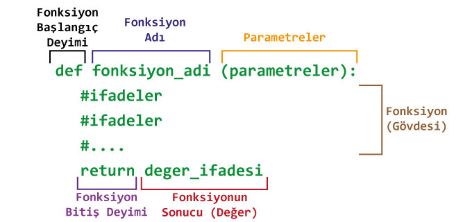

Fonksiyonlar sayesinde global (kodun tamamında geçerli) değişkenler kullanmamıza gerek kalmaz. Her fonksiyon içinde (yerell (local)) yeni değişkenler oluşturabiliriz. Fonksiyon içinde oluşturduğumuz değişken isimleri global değildir ve programın başka bir yerinde yeninden aynı değişken isimleri kullanılabilir.  
Örneğin, bir programda yüzlerce for döngüsü kullanılır. Fonksiyonları kullanmazsak her for döngüsü için farklı bir global sayaç değeri tanımlamak gerekir. for i in ..., for x in ...., for y in ....., gibi. Fakat bu kodları fonksiyon halinde yazarsak her bir fonksiyonda for i in..., for i in..., şeklinde kullanabiliriz çünkü i değerleri birbirinden etkilenmez.  
Örnek Fonksiyonlar:

```python
#Parametresiz fonksiyon örneği
def merhaba():
    print ("Merhaba Fonksiyonlar")
    return

merhaba()
```

**Etkinlik:** Çağrıldığında İstiklal Marşının ilk dörtlüğünü ekrana yazdıran fonksiyonu yazınız.

```python
#Parametreli fonksiyon örneği
def islem(i1, i2):
    sonuc = (i1*i2) + (i1//i2)
    return (sonuc)
islem(10,2)
```

**Etkinlik:** Kullanıcıdan parametre olarak aldığı kelimeyi tersten yazdıran fonksiyonu yazınız.

```python
#Fonksiyonlardaki değişkenler fonksiyon dışında tanınan bir değişken değildir. (Global değildir)
def islem(i1, i2):
    sonuc = (i1*i2) + (i1//i2)
    return (sonuc)
islem(10,2)
print(sonuc) #sonuc değişkeni fonksiyon içinde tanımlamdığı için dışarıda tanınmaz. bu satır hata verir. kapatmak için başına # koyunuz
```

```python
#Parametreli fonksiyonlarda girdi değişken tipini belirleme
def asal(sayi: int): #parametre olarak değişken tipi belirleyerek girdi parametresini integer
    durum = "Asal"
    for i in range(2,sayi):
        if sayi%i==0:
            durum = "Asal Değil"
            break
    return (print(durum))
asal(int(input("Bir Tam Sayı Giriniz: ")))
```

**Etkinlik:** Float olarak verilen parametrelerle toplama işlemi yapan fonksiyonu yazınız.

```python
#Parametreli fonksiyonlarda uygun olmayan girdi değişken tipi ile hata verir.
def asal(sayi: int): #parametre olarak değişken tipi belirleyerek girdi parametresini integer olarak
    durum = "Asal"
    for i in range(2,sayi):
        if sayi%i==0:
            durum = "Asal Değil"
            break
    return (durum)
asal(float(input("Bir Tam Sayı Giriniz: "))) #parametre olarak uygun değişken tipi vermezsek program hata verir. (Bkz. float)
```

```python
#Fonksiyonlarda parametreleri argümanlarla (değeri belirli olan değişken) çalıştırmak.
def islem(sayi: int, yil=2022):#parametre olarak değişken tipi belirleyerek girdi parametresini integer olarak
    dYili = yil-sayi
    return (print(f'Doğum yılınız: {dYili}'))
islem(int(input("Yaşınızı Giriniz: "))) #parametre 1 tane verdik ama fonksiyon tanımında 2 tane girdi var; biri parametre (sayi) diğeri argüman (yil)
```

**Etkinlik:** Parametre olarak fiyat, argüman olarak indirim oranı alan bir fonksiyonun, ürün fiyatından indirim oranı tutarında tutarı düştükten sonra ekrana yazdıran fonksiyonu yazınız.

## Fibonacci Serisi

Fibonacci dizisi, her sayının kendinden önceki ile toplanması sonucu oluşan bir sayı dizisidir. Fibonacci dizisi herhangi iki sayıdan başlayabilir. Fibonacci sayı dizisindeki sayıların birbirleriyle oranı olan ve altın oran denilen 1,618 sayısı ise doğada, sanatta ve hayatın her alanında görülen ve estetik ile bağdaştırılan bir sayıdır. Ayrıca Pascal Üçgeninde de fibonacci sayı dizisi bulunmaktadır. Aşağıdaki görselde daha iyi anlaşılır:

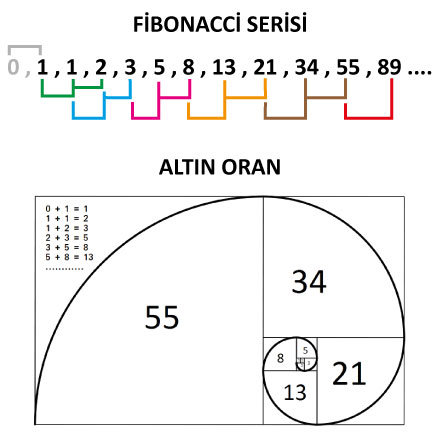

**Etkinlik:** Büyük bir çiftliğe bir dişi, bir erkek olmak üzere yeni doğmuş bir tavşan çift konur. Her tavşan çifti doğduktan bir ay sonra yetişkin hâle gelmekte ve her ay bir dişi, bir erkek olmak üzere yeni bir tavşan çifti doğurmaktadır. Tavşanların hiç ölmediği varsayıldığında çiftlikte bir yıl sonra kaç çift tavşanımız olur?  
**Bu soru 1202 yılında yazılan 'Liber Abaci (Hesap Kitabı)' isimli kitapta yazar 'Leonardo Fibonacci' tarafından sorulmuştur. Sorunun çözümü ünlü Fibonacci Dizisidir.**

```python
#Tavşan Sorusu - Fibonacci Serisi Çözümü
def fibonacci(n: int):
    terim1,terim2=0,1
    if n!=1:
        for i in range(2,n+1):
            fibDegeri=terim1+terim2
            terim1,terim2 = terim2,fibDegeri
    else: fibDegeri=terim1+terim2
    return(fibDegeri)
print(fibonacci(12)) #12.Ay'ı istediği için 12'yi girdik
```

```python
#Fibonacci serisi
def fibonacci(n: int):
    terim1,terim2=0,1
    if n!=1:
        for i in range(2,n+1):
            fiboDegeri=terim1+terim2
            print(f'{i}.terim: {fiboDegeri}')
            terim1,terim2 = terim2,fiboDegeri
    else:
        fiboDegeri="1. Terim: ",terim1+terim2,""
        return(fiboDegeri)
fibonacci(int(input("Fibonacci'nin kaç terimini yazdıralım?(Giriniz): ")))
```

**Etkinlik:** Pascal üçgenini 1.satırdan 11.satıra kadar fonksiyonla yazdırınız.

```python
#Etkinlik Çözümü
def pascal(n: int):
    for i in range(1,n + 1):
        m = 1;
        for j in range(1,i + 1):
            print(m, end =" ")
            m = int(m * (i - j) / j)
        print("")
    return
pascal(int(input("Kaçıncı satıra kadar yazılacak, giriniz: ")))
```

## İç İçe Fonksiyonlar (Nested Yapılar)

Fonksiyon içinde fonksiyon kullanarak oluşturulan yapılardır. En dıştaki fonksiyonda kullanılan değişkenler daha içerde olan fonksiyonlar tarafından kullanılabilir. Sadece iç fonksiyonda kullanılan değişken 'yerel olmayan (nonlocal)' olarak adlandırılır. Fonksiyon içinde tanımlanan fonksiyonlar varsayılan olarak dış dünyaya kapalıdır ve sadece tanımlandıkları fonksiyon içinde geçerlidirler. Örnekler:

```python
def yetkiliMi(kullanici:str, sayfa:str):
    def yetkiler(kullanici):
        kullanicilar = {
            "root":["AYARLAR","ANASAYFA","KULLANICILAR","TALEP","İŞLEM","MESAJ","İLETİŞİM"],
            "admin":["ANASAYFA","KULLANICILAR","TALEP","İŞLEM","MESAJ","İLETİŞİM"],
            "ogretmen@mail.com":["TALEP","İŞLEM","MESAJ","İLETİŞİM"],
            "ogrenci@mail.com":["TALEP","İLETİŞİM"]
        }
        return kullanicilar.get(kullanici)
    if sayfa in yetkiler(kullanici): return "Evet"
    else: return "Hayır"
print("Yetkili Mi? ",yetkiliMi(input("Kullanıcı Adınızı Giriniz: ").lower(),input("Erişmek İstediğiniz Sayfa Adını Giriniz: ").upper()))
```

**Etkinlik:** Girilen matematiksel ifadeyi işlem önceliğine göre yaparak sonucu yazdıran programı yazınız. (Parantez ve üssü işlemleri olmadan)

```python
#Etkinlik Çözümü
def parcalama (soru):
    start = 0
    parcala = []
    dortIslem=["+","-","*","/"]
    for sayac in range(0,len(soru)):
        if soru[sayac] in dortIslem:
            parcala.append(int(soru[start:sayac]))
            parcala.append(soru[sayac])
            start = sayac + 1
        if sayac == len(soru)-1: parcala.append(int(soru[start:sayac+1]))

    def islem(parcalanmis):
        sayac = 0
        while sayac < len(parcalanmis):
            if parcalanmis[sayac] == "*" or parcalanmis[sayac] == "/":
                if parcalanmis[sayac] == "*": sonuc = parcalanmis[sayac-1]*parcalanmis[sayac+1]
                if parcalanmis[sayac] == "/": sonuc = parcalanmis[sayac-1]/parcalanmis[sayac+1]
                for i in range (1,4): parcalanmis.pop(sayac-1)
                parcalanmis.insert(sayac-1,sonuc)
                sayac-=1
            sayac += 1
        sonuc = parcalanmis[0]
        for i in range (0,len(parcalanmis)-1):
            if parcalanmis[i] == "+": sonuc+=parcalanmis[i+1]
            if parcalanmis[i] == "-": sonuc-=parcalanmis[i+1]
        return sonuc

    return islem(parcala)

print(parcalama(input("İşlemi giriniz: ")))
```

## Özyinelemeli (Özyineli) Fonksiyonlar (Recursive Functions)

Kendi kendini çağıran fonksiyonlara özyinelemeli (recursive) veya özyineli fonksiyonlar denilir. Özyinelemeli fonksiyonlar, ileri bilgisayar uygulamalarında çok kullanılır. Çoğunlukla, döngülerle çözülebilen problemler, özyinelemeli fonksiyonlarla çok daha kolay olarak çözülebilir (Karaçay, 2015)  
**Özyinelemeli Fonksiyon Çalışma Mantığı**:

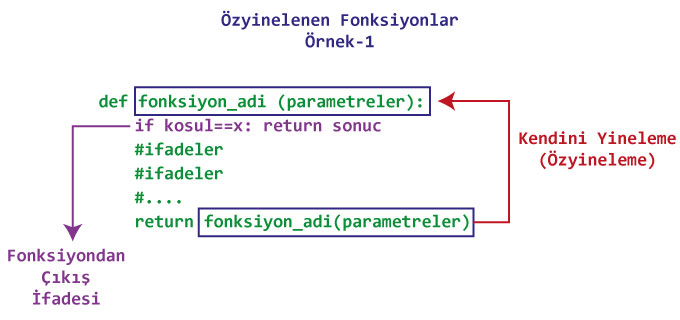

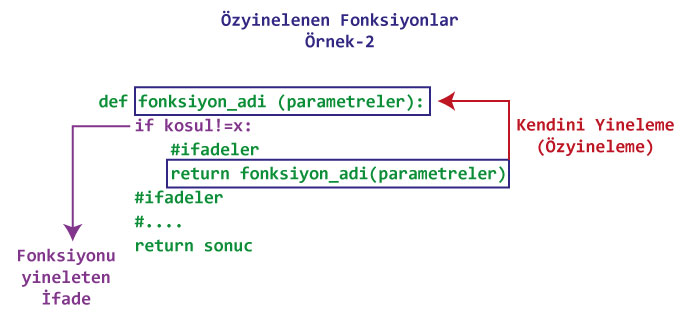

Yukarıdaki Örnek-1'de görüleceği üzere özyinelemeli fonksiyonda artık fonksiyonun **yinelenmemesi** gereken duruma özgü bir koşul (base case) ifadesi ile kendini yineletmeyen 'return' değeri verilerek fonksiyondan çıkılır ve sonuç gönderilir.  
Örnek-2'de ise fonksiyon **yinelenmesi** gereken duruma özgü koşul (recursive case) ifadesi ile yineletilir, koşula uymadığı durumda kendini yineletmeyen 'return' değeri ile fonksiyondan çıkılır ve sonuç gönderilir.  
Özyinelemeli fonkiyonların belirli bir şekli yoktur, farklı şekillerde de yapılabilir fakat konsept hepsinde aynıdır.

```python
#tavşan sorusunun (fibonacci serisi) özyinelemeli çözümü
def fibonacci(n):
    if n<3: return 1 # Base Case(Temel Durum) 3'ten küçük olunca yinelenmeyen return yazıyoruz.
    #Neden 'n<3'; çünkü n=(2,1) olunca n-1=(1,0) n-2=(0,-1) dolayısıyla geriye doğru giderek ilk terime gelmiş olduk. Yinelemenin bitmesi gerek.
    #Neden 'return 1'; çünkü ilk terime geldik ve ilk terim her halükarda 1.
    return fibonacci(n-1)+fibonacci(n-2)
print(fibonacci(12)) #12. Ayda olacak tavşan sayısı, 12.Terim
```

```python
#sıfırdan girilen pozitif sayıya kadar olan sayıların toplamını hesaplayan bir özyinelemeli fonksiyon yazalım
def toplam(sayi):
    if sayi == 1: return 1 # Base Case(Temel Durum) 1'e gelince yinelenmeyen return yazıyoruz
    return sayi + toplam(sayi - 1) # Recursive Case (Yineleten Durum) sayımızı her yinelemede birer azaltarak ve toplayarak yineliyoruz
print(toplam(int(input("Pozitif Bir Sayı Giriniz: "))))
```

```python
#sıfır'dan girilen negatif sayıya kadar olan sayıların toplamını hesaplayan bir özyinelemeli fonksiyon yazalım
def toplam(sayi):
    if sayi == -1: return -1 # Base Case(Temel Durum) -1'e gelince yinelenmeyen return yazıyoruz
    return sayi + toplam(sayi + 1) # Recursive Case (Yineleten Durum) sayımızı her yinelemede birer artırarak ve toplayarak yineliyoruz
print(toplam(int(input("Negatif Bir Sayı Giriniz: "))))
```

```python
#Girilen pozitif sayıya kadar olan sayıları çarpan bir özyinelemeli fonksiyon yazalım (faktöriyel bulma)
def carpim(sayi):
    if sayi == 1: return 1 # Base Case(Temel Durum) 1'e gelince yinelenmeyen return yazıyoruz. Neden 0 değil de 1, 0 çarpmada yutan eleman.
    return sayi * carpim(sayi - 1) # Recursive Case (Yineleten Durum) sayımızın bir eksiğini her yinelemede önceki sonuçla çarparak yineliyoruz.
print(carpim(int(input("Pozitif Bir Sayı Giriniz: "))))
```

```python
#sayılar için len() foknsiyonu kullanılmıyor malum. Basamak hesaplamak için bir özyinelemeli fonksiyon yazalım
def basamak(sayi):
    if sayi%10 < 1: return 0 # Base Case(Temel Durum) sayının 10'a bölümünden kalan ondalıklı olunca yinelenmeyen return yazıyoruz
    return basamak(sayi/10) + 1 # Recursive Case (Yineleten Durum) sayının tam kısmını bölme işlemiyle bir azaltarak (ondalıklayarak) ve +1 ile yineliyoruz
print(basamak(int(input("Bir Sayı Giriniz: "))))
```

```python
#Pascal üçgeni için bir özyinelemeli fonksiyon yazalım
def pascal(n):
    satir = [1]
    if n == 1:
        print(len(satir),".Satır: ",satir)
        return satir
    islenenSatir = pascal(n-1)
    for i in range(len(islenenSatir)-1):
        satir.append(islenenSatir[i] + islenenSatir[i+1])
    satir += [satir[0]]
    print(len(satir),".Satır: ",satir)
    return satir
pascal(int(input("Kaçıncı Satır'a Kadar Üçgen Oluşacak: ")))
```

## Global, Yerel ve Yerel Olmayan Değişkenler (Global, Local ve Nonlocal)

Fonksiyon içindeki değişkenler (local) kodun bütününde (global) geçerli değildir sadece ilgili fonksiyonunda geçerlidir. Aynı şekilde ana programda (global) geçerli değişkenler de fonksiyonun içinde (local) geçerli değil demiştik. Fakat üst hiyeraşideki değişkeni fonksiyon içinden tanımlamak, erişmek, kullanmak ve değiştirmek gerekebilir. Bu durumda 'global' ve 'nonlocal' deyimlerini kullanabiliriz. Örnekler:

```python
#global, local ve nonlocal değişkenlerin yerlerini öğrenelim.
g = "Ana Programdaki Değişken (Global)"
def yerel():
    l = "Yerel Değişken (Local)"
    def yerelOlmayan():
        nl = "Yerel Olmayan Değişken (Non Local)"
        return
    return
print(g) #hata vermez, ekrana basılır.
print(l) #hata verir.
print(nl) #hata verir.
```

```python
#global, local ve nonlocal değişkenlere erişelim
g = "Ana Programdaki Değişken (Global)"
def yerel():
    global l #globalde geçerli olacak 'l' değişkenini fonksiyon içinde tanımladık
    l = "Yerel'den tanımlanan bir global değişken" # 'l' artık global bir değişken
    global g #globaldeki g değişkenine eriştik
    g = "İçeriden Global değişkene eriştik ve değişkeni değiştirdik" #globaldeki g değişkenini değiştirdik
    x = "Şu an yerel olan, fakat yerel olmayan iç fonksiyondan erişip değişeceğimiz değişken" #bunu iç fonksiyonda manipüle edeceğiz.

    def yerelOlmayan():
        nonlocal x
        nl = "Yerel Olmayan Değişken (Non Local)"
        x = nl + " Local'in Yerine Geçti ! Tadaaa"
        return print("'nl'yi yazdırdık: ",nl)

    yerelOlmayan() #iç fonksiyonu da çalıştıralım ve x değişsin.
    return print("'x'i yazdırdık: ",x)

yerel() #Fonksiyonu çalıştırmazsak fonksiyon içinde yaptığımız işlemler gerçekleşmez. x ve nl değişkenleri bu satırla print olur. (return ettiğimiz için)
print("'g'yi yazdırdık: ",g) #hata vermez. "Ana Programdaki Değişken (Global)" çıktısını beklemeyin.
print("'l'yi yazdırdık: ",l) #hata vermez. Yerelden ana programda geçerli bir değişken oluşturduk.
```

# **Sınıf (Class) Yapısı (Nesne Yönelimli Programlama - OOP)**

Nesne yönelimli programlama şöyle açıklanabilir; martı, güvercin, baykuş, ağaçkakan, yarasa gibi kuşlar vardır, buradaki 'kuş' kavramı herhangi bir kuşu belirtmez, soyut bir kavram olarak zihinlerimizde yer edinmektedir. Bu örnekten yola çıkarak; 'baykuş', 'ağaçkakan', 'yarasa' nesneleri, 'kuş' sınıfı ifade eder. Nesne olarak her bir kuş'un (martı, baykuş, ağaçkakan, yarasa) da nitelikleri (ağırlığı, beslenme türü, yaşam alanı) ve metotları (saldırma, beslenme, uçma) vardır.  
Bazı programlama dilleri (python'da buna dahil) bu yapıyı kullanmaktadır. Bu yapı; daha rahat okunabilir kodlama, modüler iş parçacıkları, kod bakımı yapmada kolaylık, projeyi rahat geliştirme veya başka işlerde kullanma kolaylığı sağlar. Bu mantığa Nesne Yönelimli Programlama (Object Oriented Programming) denmektedir. Aşağıdaki görsele göz atalım.

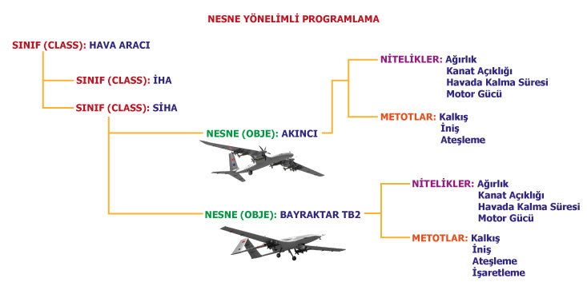

**Nesne Yönelimli Programlama Kavramları**

- **Sınıf (Class):** Kendisine ait veri türlerini belirleyeceğimiz ve bu veri türleriyle yeni nesneler üretmemizi sağlayan yapılara sınıf denir.
- **Nesne (Object):** Belirli bir sınıftan türetilen, kendisine has veri türleri ve değerleri olan, bu değerler doğrultusunda istenen davranışları sergileyen varlıklardır.
- **Metot (Object):** Bir nesnenin bazı işlevlere sahip olması gerekir. Yani bir nesnenin gerçekletirebileceği eylemler metottur. Genel olarak iki tür metot vardır.
  - Yapıcı Metot: Bir nesne oluşturulurken ilk çalışan işlevdir. Genellikle sınıfa ait ilk nesnenin niteliklere değer atayan işlevdir. Python için bu işlev '**init**()' fonksiyonudur.
  - Yıkıcı Metot: Bir nesne yok edilirken son çalışan metottur. Bir nesnenin yok edilmesi (nesneye ait tüm nitelik vb. değerlerin silinmesi) içi çalışan işlevdir. Python için bu işlev '**del**()' fonksiyonudur.
- **Miras Alma (Kalıtım) (Inheritance):** Bir sınıfın özelliklerinin, kendisinden türetilen sınıf - nesnelere aktarılmasına veya başka bir sınıfa aktarılmasına denir.
- **Erişim Belirteci:** Bir metot ya da özelliğe erişim yetkilerini belirleyen ifadelerdir.
  - public: 'Açık' ilan edilen bir sınıfın üyelerine programın herhangi bir bölümünden kolayca erişilebilir. Sınıfın veri üyeleri varsayılan olarak herkese açıktır.
  - protected: 'Korumalı' olarak bildirilen bir sınıfın üyelerine yalnızca ondan türetilmiş sınıflar erişebilir. Sınıfın veri üyelerinin önüne tek bir alt çizgi '`_`' simgesi eklenerek 'korumalı' olarak bildirilir.
  - private : 'Özel' olarak bildirilen bir sınıfın üyelerine yalnızca o sınıf içinden erişilebilir, en güvenli erişim belirleyicisidir. Sınıfın veri üyelerinin önüne çift alt çizgi '`__`' simgesi eklenerek 'özel' olarak bildirilir.

# **Hata Yakalama (Try, Except, Finally, Assert, Rasie)**

# **Dosya ve Veritabanı İşlemleri**

## OS (İşletim Sistemi) Kütüphanesi

İşletim sistemine ait yetenekleri (dosya-klasör-silme-oluşturma vb.) kullanmamızı sağlayan fonksiyonları barındırır. import os veya from os import * olarak aktarılabilir.

### OS Kütüphanesi ile Gelen Bazı Fonskiyonlar

- İşletim sistemi arabirimini öğrenmek için **'os.name()'** fonskiyonu kullanılır. (Windows mu Linux mu vb.)
- İçinde çalışılan dizin ve yolunu öğrenmek için **'os.getcwd()'** fonskiyonu kullanılır.
- İçinde çalışılan dizin ve yolun string değişken hali için **'os.curdir()'** fonskiyonu kullanılır.
- Kullanılan işletim sisteminin kullandığı dizin ayracını öğrenmek için **'os.sep()'** fonskiyonu kullanılır.
- İçinde çalışılan dizini değiştirmek için **'os.chdir()'** fonskiyonu kullanılır.
- Bir dizin içindeki dosya ve klasörleri listelemek için **'os.listdir()'** fonskiyonu kullanılır.
- Bir üst dizin içindeki dosya ve klasörleri listelemek için **'os.pardir()'** fonskiyonu kullanılır.
- Bir dosyayı başlatmak veya bir dizin açmak için **'os.startfile()'** fonskiyonu kullanılır. Sadece windows işletim sisteminde çalışır.
- İçinde çalışılan dizinin içinde yeni dizin oluşturmak için **'os.mkdir()'** fonskiyonu kullanılır.
- İçinde çalışılan dizinin içinde yeni dizin ve alt dizinler oluşturmak için **'os.mkdirs()'** fonskiyonu kullanılır.
- İçinde çalışılan dizinin içinde bulunan dizinlerin adlarını değiştirmek için **'os.rename()'** veya **'os.replace()'** fonskiyonu kullanılır. Örnek: os.rename(dizinin_Varolan_Adi,dizinin_Yeni_Adi)
- İçinde çalışılan dizinde bulunan 'dosyaları' silmek için **'os.remove()'** fonskiyonu kullanılır.
- İçinde çalışılan dizinde bulunan 'boş 1 dizini' silmek için **'os.rmdir()'** fonskiyonu kullanılır.
- İçinde çalışılan dizinde bulunan 'boş dizinleri' silmek için **'os.removedirs()'** fonskiyonu kullanılır.
- İçinde çalışılan dizinde bulunan 'dosyaya ait öznitelik bilgileri' için **'os.stat()'** fonskiyonu kullanılır.
- Bir dosya yolunun dizin kısmını elde etmek için **'os.path.dirname()'** fonskiyonu kullanılır.
- Bir dosya veya yolun varolduğunu kontrol etmek için **'os.path.exists()'** fonskiyonu kullanılır.
- Kullanıcıya ait dizin adresi için **'os.path.expanduser()'** fonskiyonu kullanılır. Örnek: os.path.expanduser('~')
- Bir değerin dizin olup olmadığını kontrol etmek için **'os.path.isdir()'** fonskiyonu kullanılır.
- Bir değerin dosya olup olmadığını kontrol etmek için **'os.path.isfile()'** fonskiyonu kullanılır.
- Verilen parametreler ile işletim sistemine ait ayracı kullanarak yol oluşturmak için **'os.path.join()'** fonskiyonu kullanılır.

**Etkinlik:** Bilgisayarınızın C: diskinde bir "Denenme" isimli klasör oluşturunuz. Ardından bu klasörün adını "Python" olarak değiştiriniz sonrasında bu klasörü siliniz.

**Etkinlik:** Bilgisayarınızda bulunan bir dosyayı açınız.

# **Projeler**

# **Kaynakça**

Darnit, J. (2017). Exact Instructions Challenge PB&J Classroom Friendly. Erişim Adresi: https://www.youtube.com/watch?v=FN2RM-CHkuI  
GeeksForGeeks, (2022). Algorithms. Erişim Adresi: https://www.geeksforgeeks.org/fundamentals-of-algorithms/  
Kara, A. (2020). Algoritma ve Çeşitleri. Erişim Adresi: https://www.datasciencearth.com/algoritma-ve-cesitleri/  
Karaçay, T. (2015). C Programlamanın Temelleri, Abaküs, İstanbul, Eylül 2015. isbn:978-6059129183. Erişim Adresi: http://www.baskent.edu.tr/~tkaracay/etudio/ders/prg/c/recursive.pdf  
Kaya, E. E. (2021). Fibonacci Dizisinden Altın Orana. Erişim Adresi: https://bilimgenc.tubitak.gov.tr/makale/fibonacci-dizisinden-altin-orana  
Şeker, S. E. (2009). Arama Algoritmaları. Erişim Adresi: https://bilgisayarkavramlari.com/2009/11/23/arama-algoritmalari-search-algorithms/  
Torun, C. (2021). Algoritma Nedir, Nerelerde Kullanılır? Erişim Adresi: https://bilimgenc.tubitak.gov.tr/algoritma-nedir  
Zaczyński, B. (2020). Bitwise Operators in Python. Erişim Adresi: https://realpython.com/python-bitwise-operators/